# HW Problem 2

# Module 8-HW Problem 2

```r
zombies<-read.csv("C:/Users/EmmaKristina/Desktop/zombies.csv",header=T,sep=",")
head(zombies)
```

```
##   X.2 X.1 X id first_name last_name gender   height   weight
## 1   1   1 1  1      Sarah    Little Female 62.88951 132.0872
## 2   2   2 2  2       Mark    Duncan   Male 67.80277 146.3753
## 3   3   3 3  3    Brandon     Perez   Male 72.12908 152.9370
## 4   4   4 4  4      Roger   Coleman   Male 66.78484 129.7418
## 5   5   5 5  5      Tammy    Powell Female 64.71832 132.4265
## 6   6   6 6  6    Anthony     Green   Male 71.24326 152.5246
##   zombies_killed years_of_education                           major
## 1              2                  1                medicine/nursing
## 2              5                  3 criminal justice administration
## 3              1                  1                       education
## 4              5                  6                  energy studies
## 5              4                  3                       logistics
## 6              1                  4                  energy studies
##        age
## 1 17.64275
## 2 22.58951
## 3 21.91276
## 4 18.19058
## 5 21.10399
## 6 21.48355
```

### [1] Calculate the population mean and standard deviation for each quantitative random variable (height, weight, age, number of zombies killed, and years of education).

```r
#Each of these variables is a numeric vector within the "zombies" data frame. Since neither sample nor population mean involve degrees of freedom (i.e., they are both calculated using the total n), you can use the built in "mean" function to get the average of each variable
meanheight<-mean(zombies$height)
meanweight<-mean(zombies$weight)
meanage<-mean(zombies$age)
meanzombies_killed<-mean(zombies$zombies_killed)
meaneducation<-mean(zombies$years_of_education)
#Since we want the standard deviation of a population, rather than a mean, our sd function must include the population variance rather than sample variance. To calculate the POPULATION variance, rather than sample variance, you need to divide the sum of squares by N rather than degrees of freedom (in this case n-1)
sdheight<-sqrt(sum((zombies$height-meanheight)^2)/length(zombies$height))
sdweight<-sqrt(sum((zombies$weight-meanweight)^2)/length(zombies$weight))
sdage<-sqrt(sum((zombies$age-meanage)^2)/length(zombies$age))
sdzombies_killed<-sqrt(sum((zombies$zombies_killed-meanzombies_killed)^2)/length(zombies$zombies_killed))
sdeducation<-sqrt(sum((zombies$years_of_education-meaneducation)^2)/length(zombies$years_of_education))
#Results
meanheight
```

```
## [1] 67.6301
```

```r
sdheight
```

```
## [1] 4.30797
```

```r
meanweight
```

```
## [1] 143.9075
```

```r
sdweight
```

```
## [1] 18.39186
```

```r
meanage
```

```
## [1] 20.04696
```

```r
sdage
```

```
## [1] 2.963583
```

```r
meanzombies_killed
```

```
## [1] 2.992
```

```r
sdzombies_killed
```

```
## [1] 1.747551
```

```r
meaneducation
```

```
## [1] 2.996
```

```r
sdeducation
```

```
## [1] 1.675704
```

### [2] Use ggplot and make boxplots of each of these variable by gender.

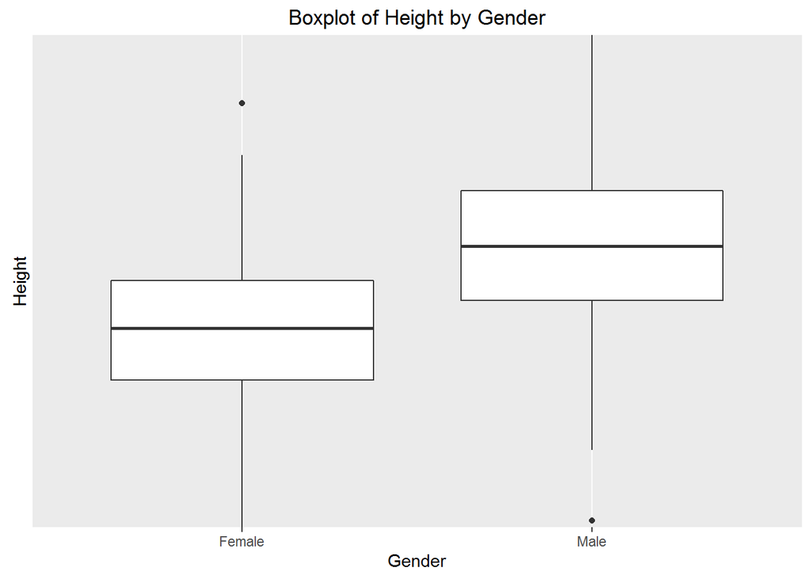

```r
#The first argument you need to input into ggplot is the data argument. In this case you're telling it to pull its data from the data frame "zombies". You then need to tell it which variables/columns you want on the x and y axes. You then close off the ggplot command and add a second command (using the "+" sign) to tell it that you want the chosen variables displayed in a boxplot format. You can then add the scale commands and name your axes, as well as the title command to title your graph
library(ggplot2)
height_by_gender<-ggplot(zombies,aes(x=zombies$gender,y=zombies$height))+geom_boxplot()+scale_x_discrete(name="Gender")+scale_y_discrete(name="Height")+ggtitle("Boxplot of Height by Gender")
weight_by_gender<-ggplot(zombies,aes(x=zombies$gender,y=zombies$weight))+geom_boxplot()+scale_x_discrete(name="Gender")+scale_y_discrete(name="Weight")+ggtitle("Boxplot of Weight by Gender")
age_by_gender<-ggplot(zombies,aes(x=zombies$gender,y=zombies$age))+geom_boxplot()+scale_x_discrete(name="Gender")+scale_y_discrete(name="Age")+ggtitle("Boxplot of Age by Gender")
zombies_killed_by_gender<-ggplot(zombies,aes(x=zombies$gender,y=zombies$zombies_killed))+geom_boxplot()+scale_x_discrete(name="Gender")+scale_y_discrete(name="Number of Zombies Killed")+ggtitle("Boxplot of Number of Zombies Killed by Gender")
education_by_gender<-ggplot(zombies,aes(x=zombies$gender,y=zombies$years_of_education))+geom_boxplot()+scale_x_discrete(name="Gender")+scale_y_discrete(name="Years of Education")+ggtitle("Boxplot of Years of Education by Gender")
#Here are the resulting boxplots:
height_by_gender
```

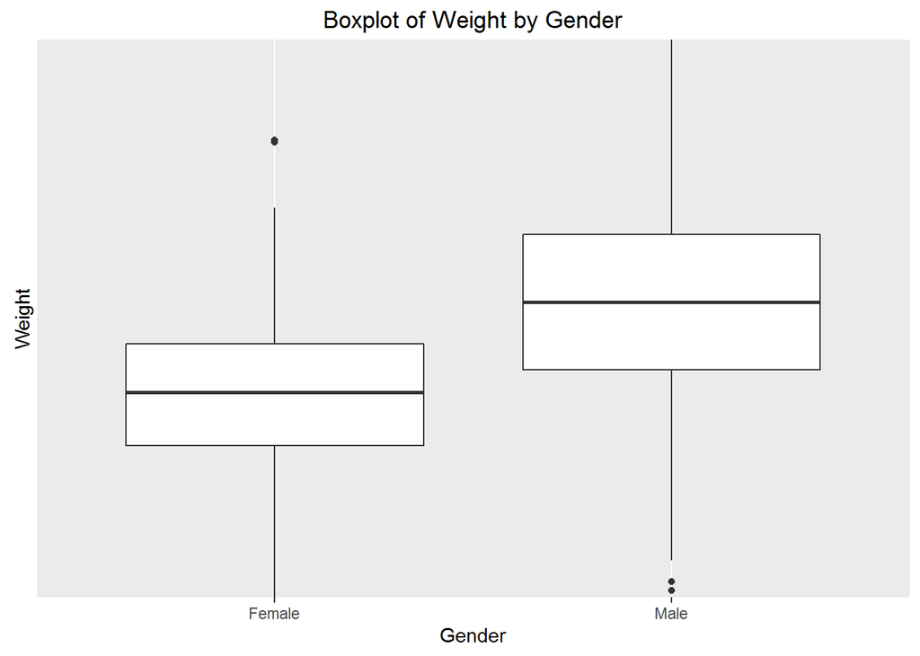

```r
weight_by_gender
```

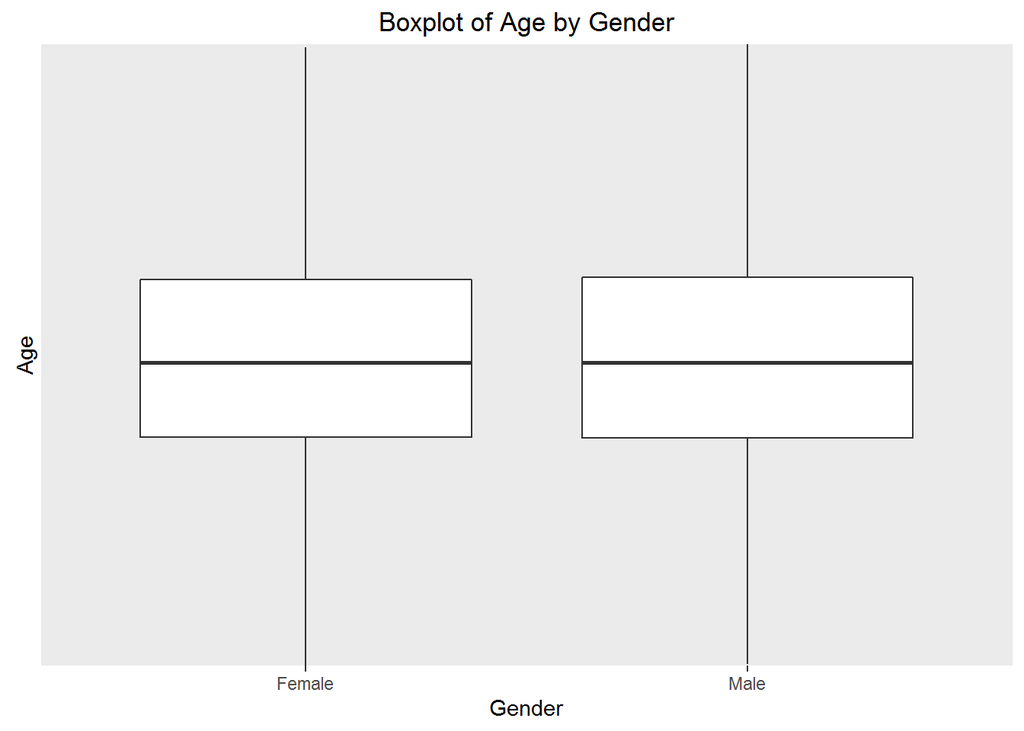

```r
age_by_gender
```

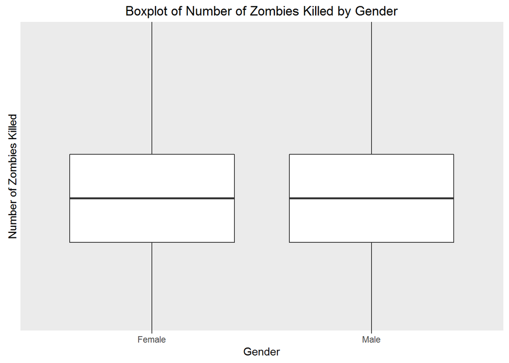

```r
zombies_killed_by_gender
```

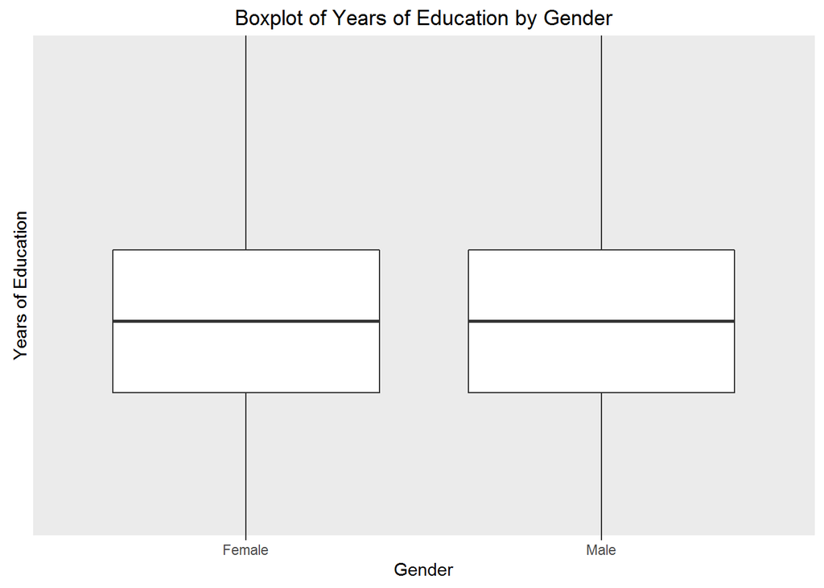

```r
education_by_gender
```

### [3] Use ggplot and make a scatterplots of height and weight in relation to age. Do these variables seem to be related? In what way?

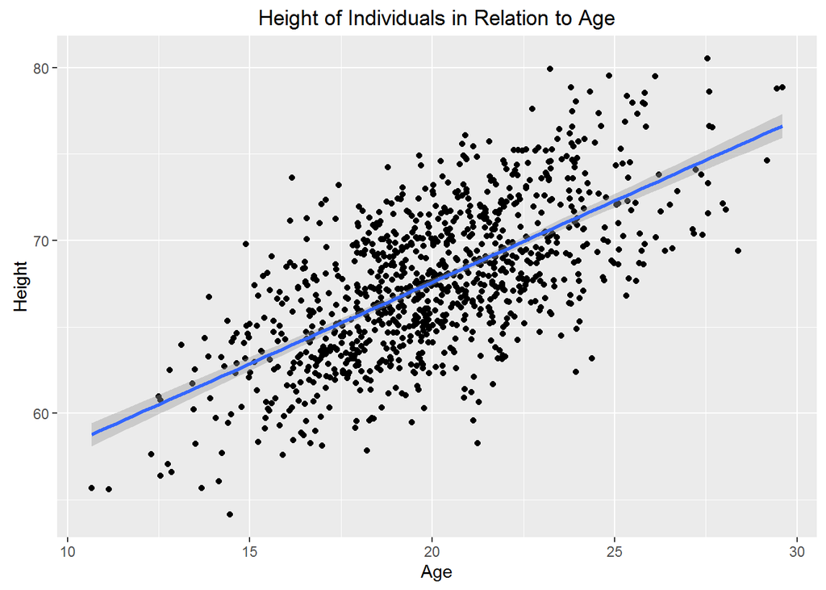

```r
library(ggplot2)
heightXage<-ggplot(zombies,aes(x=zombies$age,y=zombies$height))+geom_point()+scale_x_continuous(name="Age")+scale_y_continuous(name="Height")+ggtitle("Height of Individuals in Relation to Age")+geom_smooth(method = "lm", se = TRUE)
heightXage
```

```r
heightXage.lm<-lm(zombies$age~zombies$height,data = zombies)
summary(heightXage.lm)$r.squared
```

```
## [1] 0.4203968
```

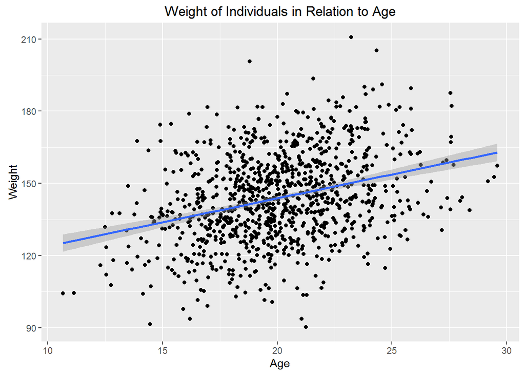

```r
weightXage<-ggplot(zombies,aes(x=zombies$age,y=zombies$weight))+geom_point()+scale_x_continuous(name="Age")+scale_y_continuous(name="Weight")+ggtitle("Weight of Individuals in Relation to Age")+geom_smooth(method = "lm", se = TRUE)
weightXage
```

```r
weightXage.lm<-lm(zombies$age~zombies$weight,data=zombies)
summary(weightXage.lm)$r.squared
```

```
## [1] 0.1026051
```

```r
#Based on the scatterplots, both height and weight appear to be positively correlated with age, though the correlation appears to be stronger for heightXage judging by the lower degree of deviation of the data points from the regression line (i.e., relatively smaller residuals than observed in weightXage). That being said, both show a relatively large degree of spread around the regression lines an thus I did not anticipate a high coefficient of determination (r^2) for either. Results of the linear regressions confirm this theory in that both relationships have relatively low r-squared values: 0.4204 and 0.1026 for heightXage and weightXage, respectively. The fact that heightXage has a higher r-squared than weightXage also supports my earlier predication of height being more strongly correlated with age than is weight.
```

### [4] Using histograms and Q-Q plots, check whether the quantitative variables seem to be drawn from a normal distribution. Which seem to be and which do not? For those that are not, can you determine what common distribution they are drawn from?

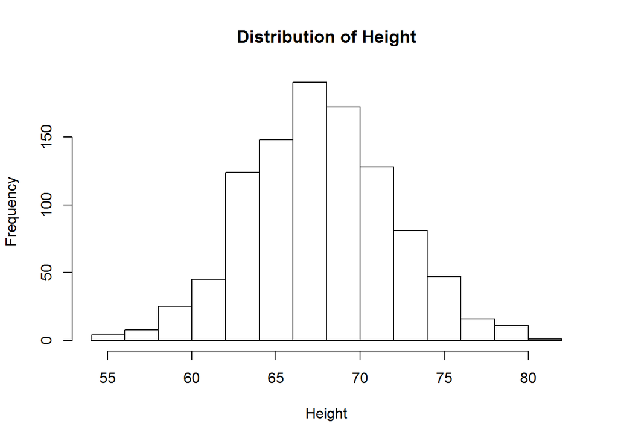

```r
#Analysis of "Height" distribution via histogram and Q-Q plot
hist(zombies$height,main="Distribution of Height",xlab="Height")
```

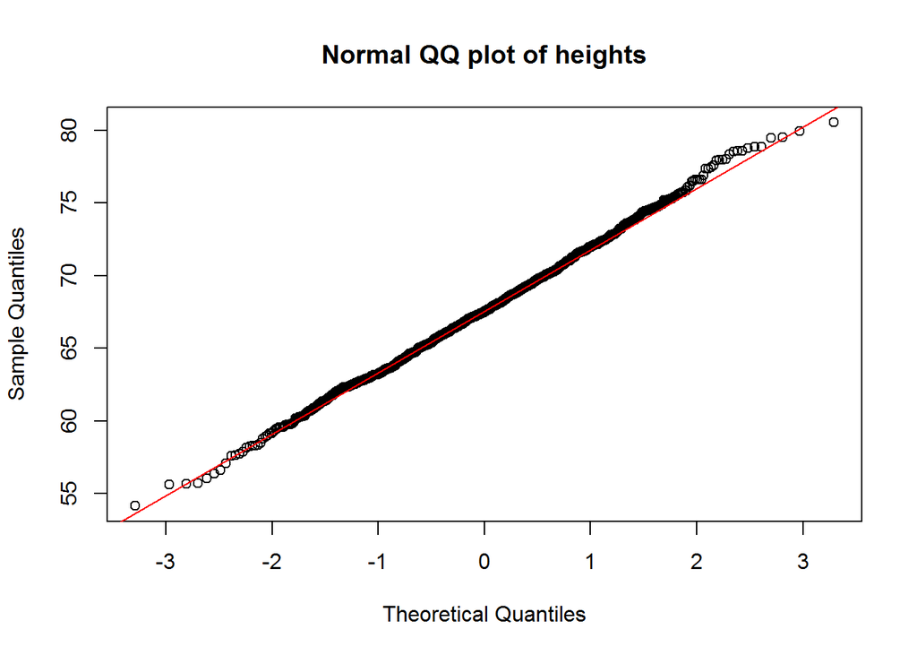

```r
qqnorm(zombies$height,main="Normal QQ plot of heights")
qqline(zombies$height,col="red")
```

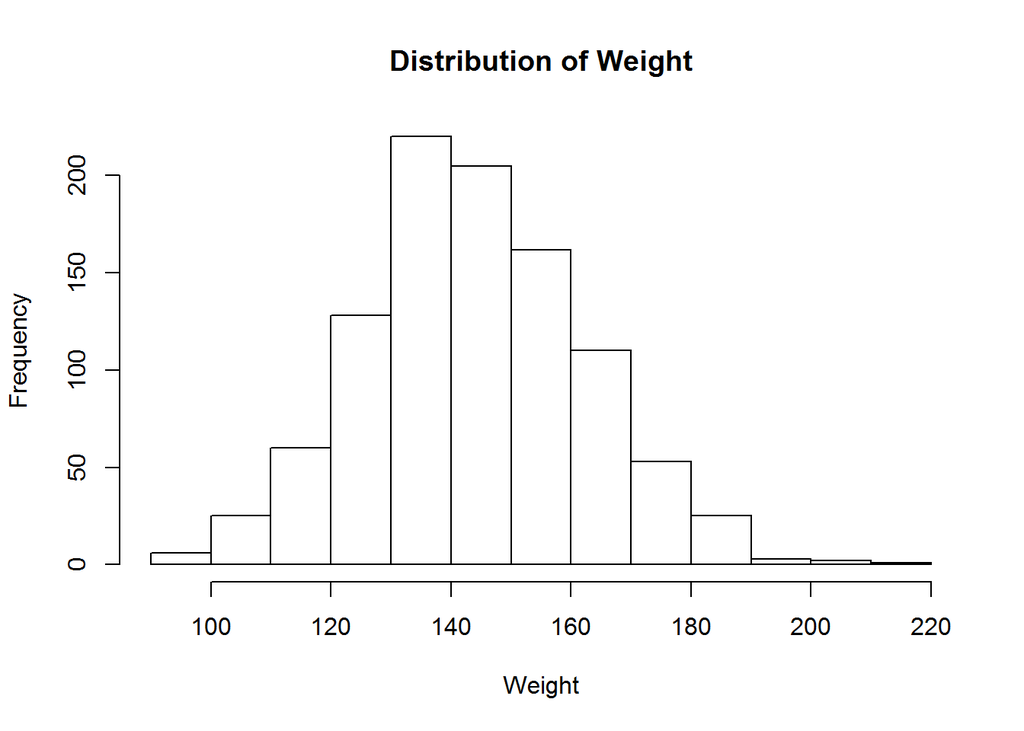

```r
#Analysis of "Weight" distribution via histogram and Q-Q plot
hist(zombies$weight,main="Distribution of Weight",xlab="Weight")
```

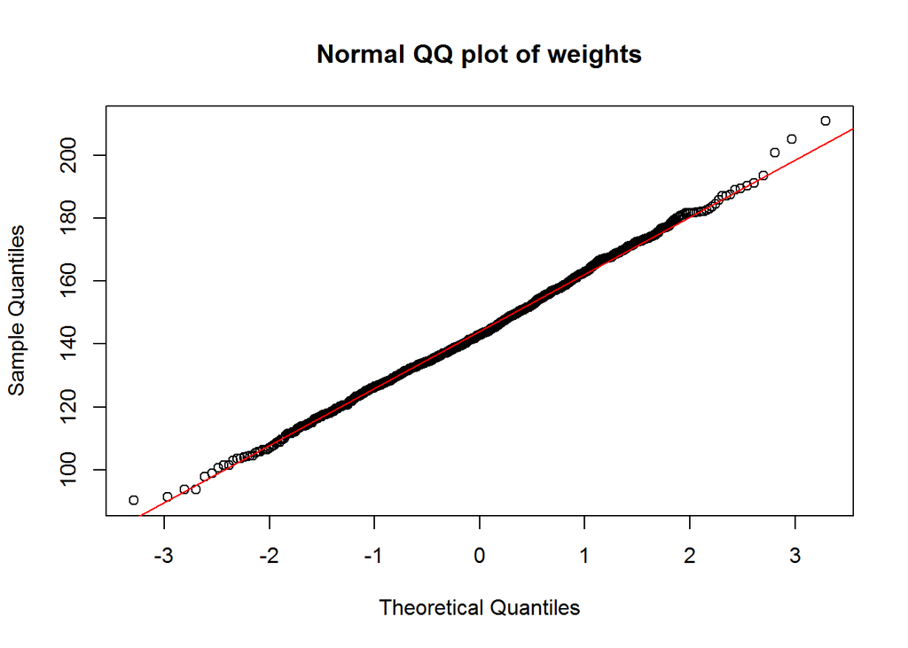

```r
qqnorm(zombies$weight,main="Normal QQ plot of weights")
qqline(zombies$weight,col="red")
```

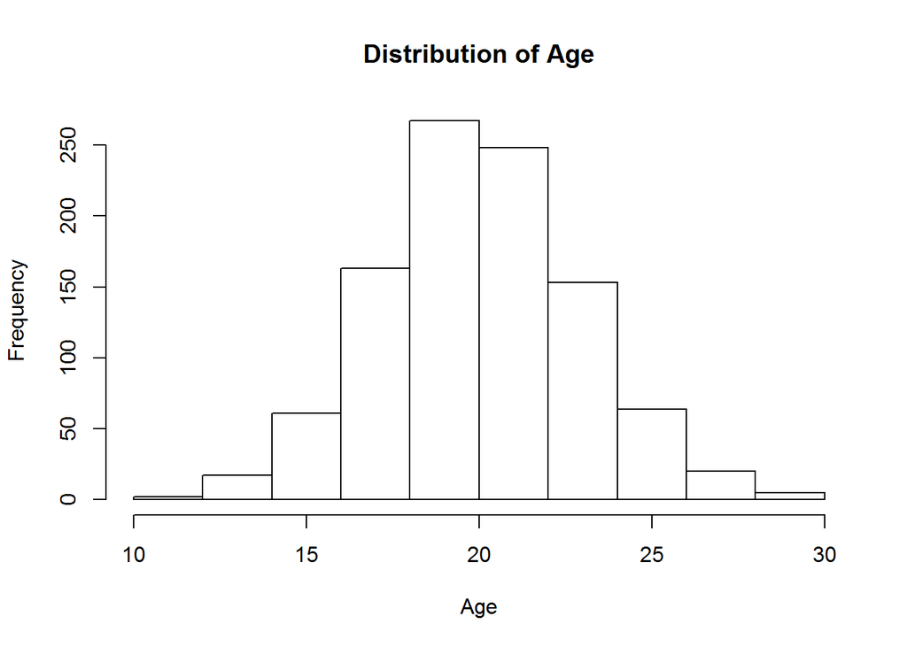

```r
#Analysis of "Age" distribution via histogram and Q-Q plot
hist(zombies$age,main="Distribution of Age",xlab="Age")
```

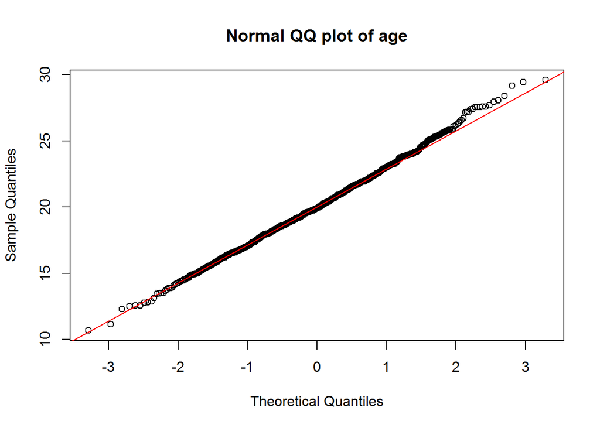

```r
qqnorm(zombies$age,main="Normal QQ plot of age")
qqline(zombies$age,col="red")
```

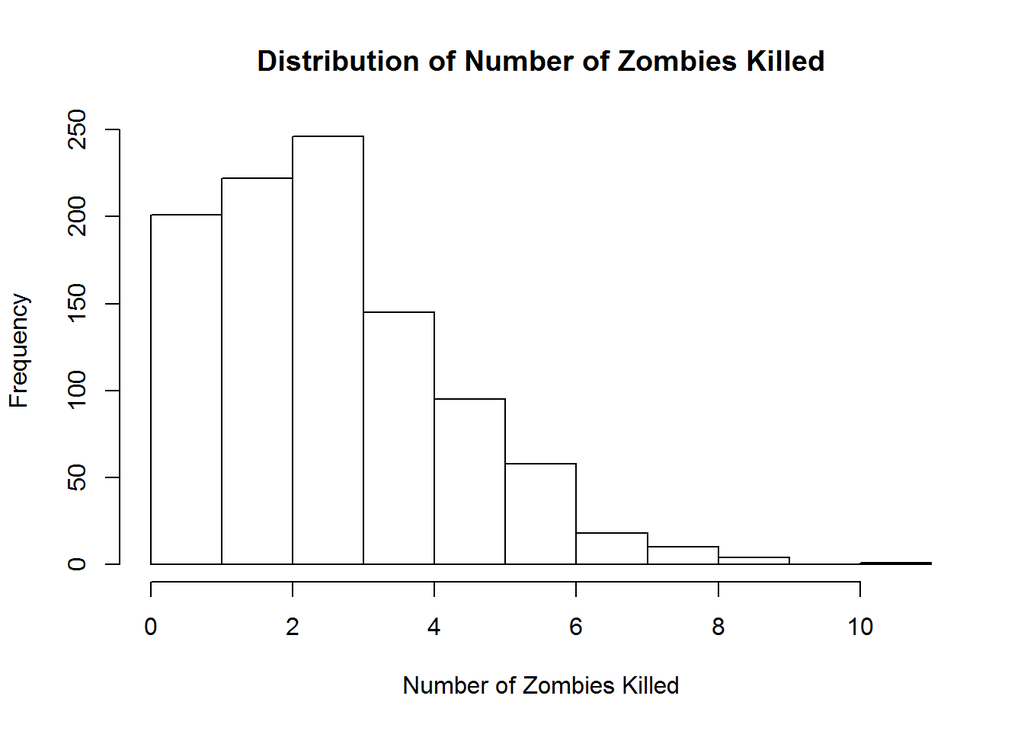

```r
#Analysis of "Zombies_killed" distribution via histogram and Q-Q plot
hist(zombies$zombies_killed,main="Distribution of Number of Zombies Killed",xlab="Number of Zombies Killed")
```

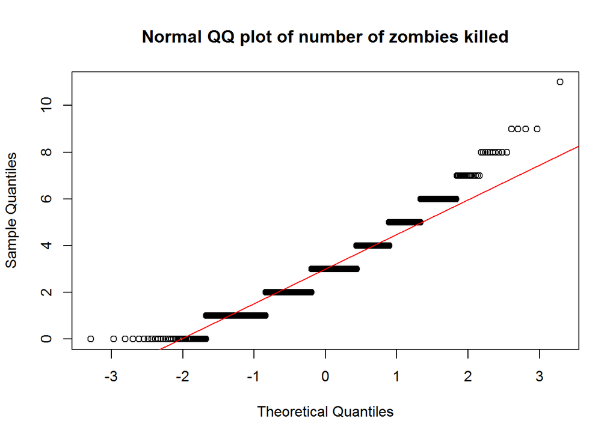

```r
qqnorm(zombies$zombies_killed,main="Normal QQ plot of number of zombies killed")
qqline(zombies$zombies_killed,col="red")
```

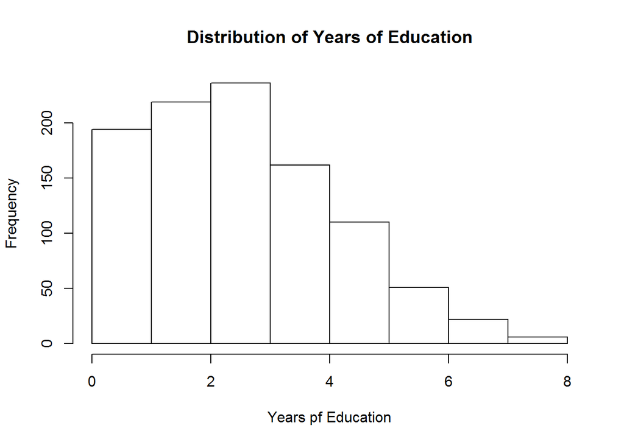

```r
#Analysis of "Years_of_Education" distribution via histogram and Q-Q plot
hist(zombies$years_of_education,main="Distribution of Years of Education",xlab="Years pf Education")
```

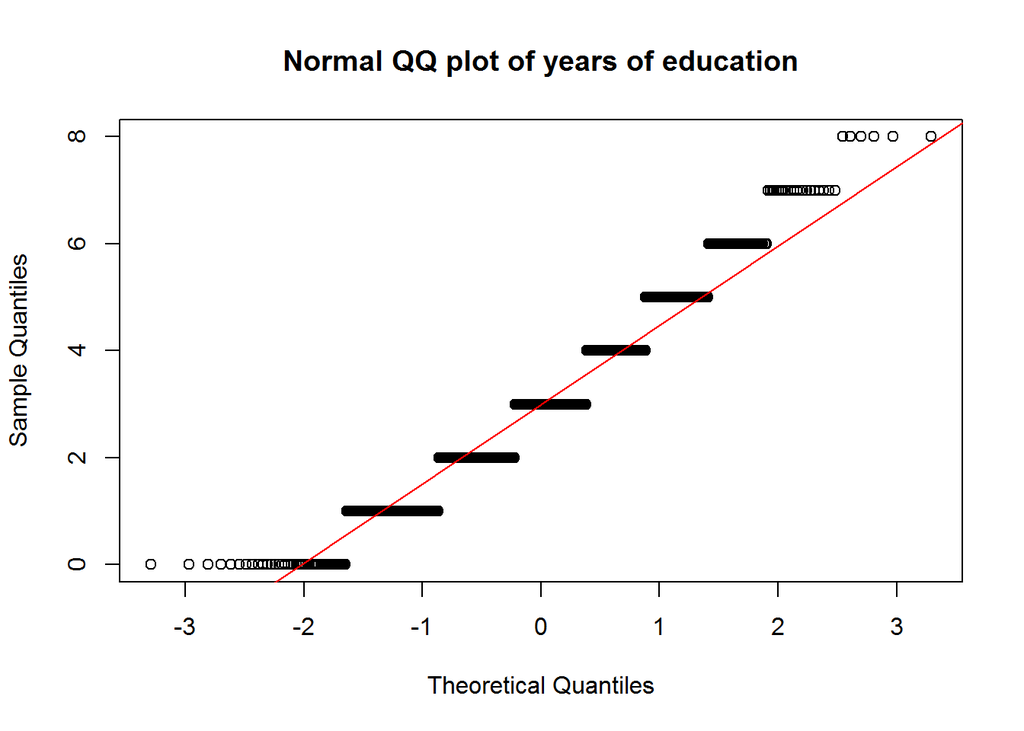

```r
qqnorm(zombies$years_of_education,main="Normal QQ plot of years of education")
qqline(zombies$years_of_education,col="red")
```

```r
#Interpretation of distributions: The first three variable (height, weight, age) clearly appear to follow a normal distribution as evidenced by histograms, in which the data frequencies follow a bell-shaped pattern that is roughly centered over the mean, and in the Q-Q plots in which the points align almost perfectly with the "expectation" line. The last two variables (zombies_killed and years_of_education) deviate significantly from this pattern, though in similar ways. The histograms show a strong positive scew and the points on the Q-Q plots are arranged as more of a series of incremental steps. Based on the evidence, I would guess that these two variables most closely match a Poisson distribution.
```

### [5] Now use the sample() function to sample ONE subset of 30 zombies (without replacement) from this population and calculate the mean and sample standard deviation for each variable. Also estimate the standard error for each variable and construct the 95% confidence interval for each mean. Note that for the variables that are not drawn from the normal distribution, you will need to base your estimate of the CIs on some different distribution.

```r
#First subset the quantitative variables "zombies" data frame assign it to a new object (numvars). Then subset the new object to extract a random sample of 30 rows (in this case, rows=zombies)
numvars<-data.frame(zombies$height,zombies$weight,zombies$age,zombies$zombies_killed,zombies$years_of_education)
summary(numvars)
```

```
##  zombies.height  zombies.weight    zombies.age    zombies.zombies_killed
##  Min.   :54.15   Min.   : 90.29   Min.   :10.66   Min.   : 0.000
##  1st Qu.:64.68   1st Qu.:131.81   1st Qu.:18.07   1st Qu.: 2.000
##  Median :67.50   Median :142.89   Median :19.90   Median : 3.000
##  Mean   :67.63   Mean   :143.91   Mean   :20.05   Mean   : 2.992
##  3rd Qu.:70.38   3rd Qu.:156.28   3rd Qu.:21.94   3rd Qu.: 4.000
##  Max.   :80.53   Max.   :210.79   Max.   :29.59   Max.   :11.000
##  zombies.years_of_education
##  Min.   :0.000
##  1st Qu.:2.000
##  Median :3.000
##  Mean   :2.996
##  3rd Qu.:4.000
##  Max.   :8.000
```

```r
str(numvars)
```

```
## 'data.frame':    1000 obs. of  5 variables:
##  $ zombies.height            : num  62.9 67.8 72.1 66.8 64.7 ...
##  $ zombies.weight            : num  132 146 153 130 132 ...
##  $ zombies.age               : num  17.6 22.6 21.9 18.2 21.1 ...
##  $ zombies.zombies_killed    : int  2 5 1 5 4 1 0 4 9 2 ...
##  $ zombies.years_of_education: int  1 3 1 6 3 4 4 0 3 3 ...
```

```r
sample<-numvars[sample(nrow(numvars),30,replace=F),]
sample
```

```
##     zombies.height zombies.weight zombies.age zombies.zombies_killed
## 898       69.87416       169.4200    18.99324                      5
## 404       59.56853       101.4664    16.53850                      5
## 209       75.45580       175.5042    23.86443                      4
## 259       62.03273       135.3092    17.67434                      7
## 502       70.11203       159.7062    20.07750                      0
## 577       66.80483       141.5643    19.33480                      2
## 205       72.67681       161.1856    20.02906                      2
## 449       64.90341       132.8371    19.24091                      2
## 629       73.84898       159.3562    23.12811                      3
## 17        72.23608       171.0235    18.74897                      5
## 270       67.64806       130.5163    25.58631                      2
## 541       63.17451       157.1891    17.79204                      1
## 877       64.34188       129.1294    19.18535                      1
## 185       69.68828       166.5898    17.94201                      4
```

[output cut: 47 more lines]

```r
#height--Normal distribution
m<-mean(sample$zombies.height)
sd<-sd(sample$zombies.height)
sample_std_error<-sd(sample$zombies.height)/sqrt(length(sample$zombies.height))
sample_std_error
```

```
## [1] 0.8243321
```

```r
lower<-m-qnorm(1-0.025)*sample_std_error
upper<-m+qnorm(1-0.025)*sample_std_error
ci<-c(lower,upper)
ci
```

```
## [1] 65.79485 69.02617
```

```r
#weight--Normal distribution
m<-mean(sample$zombies.weight)
sd<-sd(sample$zombies.weight)
sample_std_error<-sd(sample$zombies.weight)/sqrt(length(sample$zombies.weight))
sample_std_error
```

```
## [1] 3.847885
```

```r
lower<-m-qnorm(1-0.025)*sample_std_error
upper<-m+qnorm(1-0.025)*sample_std_error
ci<-c(lower,upper)
ci
```

```
## [1] 137.2147 152.2982
```

```r
#age--Normal distribution
m<-mean(sample$zombies.age)
sd<-sd(sample$zombies.age)
sample_std_error<-sd(sample$zombies.age)/sqrt(length(sample$zombies.age))
sample_std_error
```

```
## [1] 0.5240058
```

```r
lower<-m-qnorm(1-0.025)*sample_std_error
upper<-m+qnorm(1-0.025)*sample_std_error
ci<-c(lower,upper)
ci
```

```
## [1] 18.80599 20.86005
```

```r
#zombies_killed--Poisson distribution
m<-mean(sample$zombies.zombies_killed)
sd<-sd(sample$zombies.zombies_killed)
sample_std_error<-sd(sample$zombies.zombies_killed)/sqrt(length(sample$zombies.zombies_killed))
sample_std_error
```

```
## [1] 0.319782
```

```r
lower<-m-qpois(1-0.025,lambda = m)*sample_std_error
upper<-m+qpois(1-0.025,lambda = m)*sample_std_error
ci<-c(lower,upper)
ci
```

```
## [1] 0.7948592 5.2718074
```

```r
#education--Poisson distribution
m<-mean(sample$zombies.years_of_education)
sd<-sd(sample$zombies.years_of_education)
sample_std_error<-sd(sample$zombies.years_of_education)/sqrt(length(sample$zombies.years_of_education))
sample_std_error
```

```
## [1] 0.1877473
```

```r
lower<-m-qpois(1-0.025,lambda = m)*sample_std_error
upper<-m+qpois(1-0.025,lambda = m)*sample_std_error
ci<-c(lower,upper)
ci
```

```
## [1] 1.540183 3.793150
```